# Word frequency changes over time

Xiyao Yan(xy2431)

2020/2/4

```r
library(tidyverse)
library(tidytext)
library(plotly)
library(DT)
library(tm)
library(data.table)
library(scales)
library(wordcloud2)
library(gridExtra)
library(ngram)
library(shiny)
```

> 1.Did words most used in lyrics vary along with time?  
> ShinyApp is used to draw the wordcloud to find the answer

### Load the processed lyrics data

We use the processed data and artist information for our analysis, and use the factor “period” to make classificaiton for the year. Besides, we create a named vector to make preparation for visualization.

```r
# load lyrics data
load('../output/processed_lyrics.RData')

##take a look of year,year 112, year 702 and year 1968 need to be deleted
table(dt_lyrics$year)
```

```
##
##   112   702  1968  1970  1971  1972  1973  1974  1975  1976  1977  1978
##     1     1     1   112   125   119   172   120    82    47   205   137
##  1979  1980  1981  1982  1983  1984  1985  1986  1987  1988  1989  1990
##   105   141    99   134    85   129   123   128    71   133   137   809
##  1991  1992  1993  1994  1995  1996  1997  1998  1999  2000  2001  2002
##   105   483   356   374   409   484   424   441   486   672   738   880
##  2003  2004  2005  2006  2007  2008  2009  2010  2011  2012  2013  2014
##  1199  1496  2793 42457 30600  8220  4094  4187  3340  3321  3450  4880
##  2015  2016
##  3286  3313
```

```r
dt_lyrics_time<-dt_lyrics%>%
  filter(year>1969)%>%
  mutate("period" = cut(year,breaks = seq(1969,2019,10),
            labels = c("1970s","1980s","1990s","2000s","2010s")))%>%
  select(song,year,period,everything())

head(dt_lyrics_time)
```

```
## # A tibble: 6 x 8
##   song     year period artist genre  lyrics           id stemmedwords
##   <chr>   <dbl> <fct>  <chr>  <chr>  <chr>         <int> <chr>
## 1 when-y~  2009 2000s  a      Hip-H~ "I stopped b~     1 stop house call h~
## 2 carele~  2009 2000s  a      Hip-H~ "I feel so u~     2 unsure hand lead ~
## 3 2-59     2007 2000s  a      Hip-H~ "Mark:] Sund~     3 mark sunday footb~
## 4 power-~  2007 2000s  a      Hip-H~ "[Chris:] Fa~     4 chris fallin fant~
## 5 you-re~  2007 2000s  a      Hip-H~ "something i~     5 touch hold hand h~
## 6 nothing  2007 2000s  a      Hip-H~ "Nothing\nAn~     6 nothings youre yo~
```

```r
corpus_time <- VCorpus(VectorSource(dt_lyrics_time$stemmedwords))
word_tibble_time <- tidy(corpus_time) %>%
  select(text) %>%
  mutate(id = row_number()) %>%
  unnest_tokens(word, text)

time_list <- c("1970s", "1980s", "1990s", "2000s", "2010s")
```

### Specify the user interface for the R Shiny app

```r
# Define UI for app that draws a histogram ----
ui <- navbarPage(strong("Lyrics Analysis"),
  tabPanel("Overview",
    titlePanel("Most frequent words"),
    # Sidebar layout with input and output definitions ----
    sidebarLayout(
      # Sidebar panel for inputs ----
      sidebarPanel(
        sliderInput(inputId = "nwords1",
                    label = "Number of terms in the first word cloud:",
                    min = 5, max = 100, value = 50),
        selectInput('period1', 'Period of the first word cloud',
                    time_list, selected='1970s')

    ),
    # Main panel for displaying outputs ----
    mainPanel(
      wordcloud2Output(outputId = "WC1", height = "300")
    )
  ),
  hr(),
  sidebarLayout(
      # Sidebar panel for inputs ----
      sidebarPanel(
        sliderInput(inputId = "nwords2",
                    label = "Number of terms in the second word cloud:",
                    min = 5, max = 100, value = 50),
        selectInput('period2', 'Period of the second word cloud',
                    time_list, selected='1980s')
    ),
    # Main panel for displaying outputs ----
    mainPanel(
      wordcloud2Output(outputId = "WC2", height = "300")
    )
  )
           ),
  tabPanel("Data",
           DT::dataTableOutput("table"))
)
```

### Define server logic required for ui —-

```r
server <- function(input, output) {
  output$WC1 <- renderWordcloud2({
    count(filter(word_tibble_time, id %in% which(dt_lyrics_time$period == input$period1)), word, sort = TRUE) %>%
      slice(1:input$nwords1) %>%
      wordcloud2(size=0.6, rotateRatio=0.2)
  })
  output$WC2 <- renderWordcloud2({
    count(filter(word_tibble_time, id %in% which(dt_lyrics_time$period == input$period2)), word, sort = TRUE) %>%
      slice(1:input$nwords2) %>%
      wordcloud2(size=0.6, rotateRatio=0.2)
  })
  output$table <- DT::renderDataTable({
    DT::datatable(dt_lyrics_time)
  })
}
```

### Run the R Shiny app

```r
shinyApp(ui, server)
```

Shiny applications not supported in static R Markdown documents

Using the word cloud we can find some words like “LOVE”, “BABY” and “TIME” that remain the most frequent occurence throughout the time. However, there are also some changes.If we limit the number of terms displayed word cloud, we’ll find some words like “PEOPLE” and “WAITING”, which occured frequently in 1970s, became less popular in the following year while the word “GIRL” was used more often.

> 2.Can some trends be applied to the frquency?

To see the weather there are some trend in the frquency of words, the top 20 of words are used. Based on the output of part 1, we can find the number of songs varis a lot with year(47 in 1976 VS 42457 in 2006), thus the conclusion will be got from the analysis of the ratio(occurence of the word/total words used)

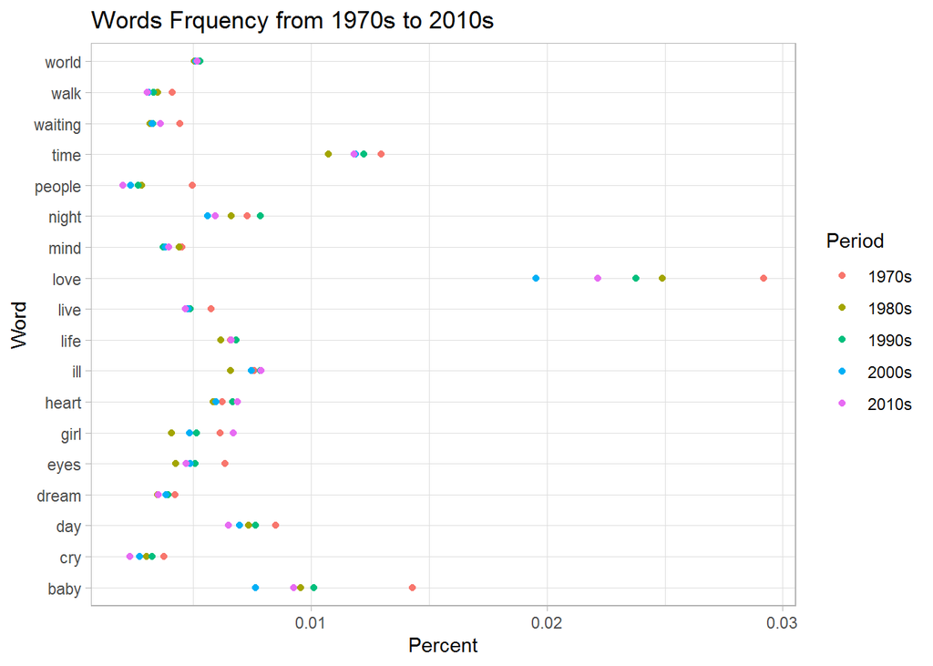

```r
word_frquence_time<-left_join(dt_lyrics_time,word_tibble_time,"id")%>%
  select(id,period,word)

count<-word_frquence_time%>%
  group_by(period)%>%
  count(word)%>%
  group_by(period)%>%
  arrange(period,-n)%>%
  pivot_wider(names_from = 1,values_from = 3)

sum<-apply(count[,2:6],2,sum,na.rm = T)

##The word "IVE" and "YOURE" can be seen as stemword, thus can be removed from the data.
data<-count[1:20,]%>%
  filter( word != "ive" & word != "youre")%>%
  mutate(`1970s` = `1970s`/sum[1],
         `1980s` = `1980s`/sum[2],
         `1990s` = `1990s`/sum[3],
         `2000s` = `2000s`/sum[4],
         `2010s` = `2010s`/sum[5])

g1<-ggplot(data,aes(word))+
  geom_point(aes(y = `1970s`,col = "1970s"))+
  geom_point(aes(y = `1980s`,col = "1980s"))+
  geom_point(aes(y = `1990s`,col = "1990s"))+
  geom_point(aes(y = `2000s`,col = "2000s"))+
  geom_point(aes(y = `2010s`,col = "2010s"))+
  coord_flip()+
  labs(title = "Words Frquency from 1970s to 2010s",
       x = "Word",
       y = "Percent")+
  scale_colour_discrete(name  ="Period")+
  theme_light()

g1
```

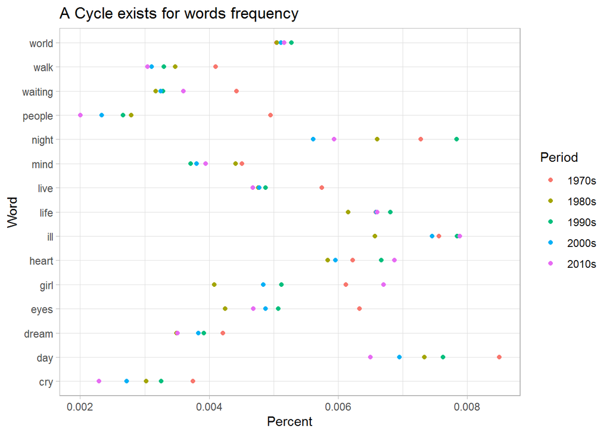

```r
###To have a more specific look of the trend, separate top3 words(i.e LOVE, BABY AND TIME) from others to have two new graphs.
g2<-ggplot(data[-(1:3),],aes(word))+
  geom_point(aes(y = `1970s`,col = "1970s"))+
  geom_point(aes(y = `1980s`,col = "1980s"))+
  geom_point(aes(y = `1990s`,col = "1990s"))+
  geom_point(aes(y = `2000s`,col = "2000s"))+
  geom_point(aes(y = `2010s`,col = "2010s"))+
  coord_flip()+
  labs(title = "A Cycle exists for words frequency",
       y = "Percent",
       x = "Word")+
  scale_colour_discrete(name  ="Period")+
  theme_light()
g2
```

It turns out there seems to be a cycle for the specific word, words would be popular again years later. However, the distance from the highest to the lowest and the period for the cycle may differ from word to word. For example,the range for word “WORLD” is much smaller than that for “NIGHT”, period for word “EYES” and “NIGHT” are more likely to be 20 years while it for word “MIND” may be longer than 50 years.

> 3.Can predict words frequency using rules we found above?

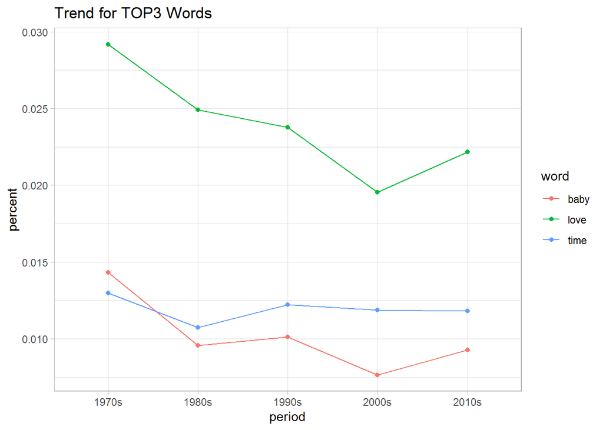

```r
g3<-data[1:3,]%>%
  pivot_longer(2:6,names_to = "period",values_to = "percent")%>%
  ggplot()+
  geom_point(aes(period,percent,col = word))+
  geom_line(aes(x = rep(1:5,3),percent,col = word))+
  labs(title = "Trend for TOP3 Words")+
  theme_light()

g3
```

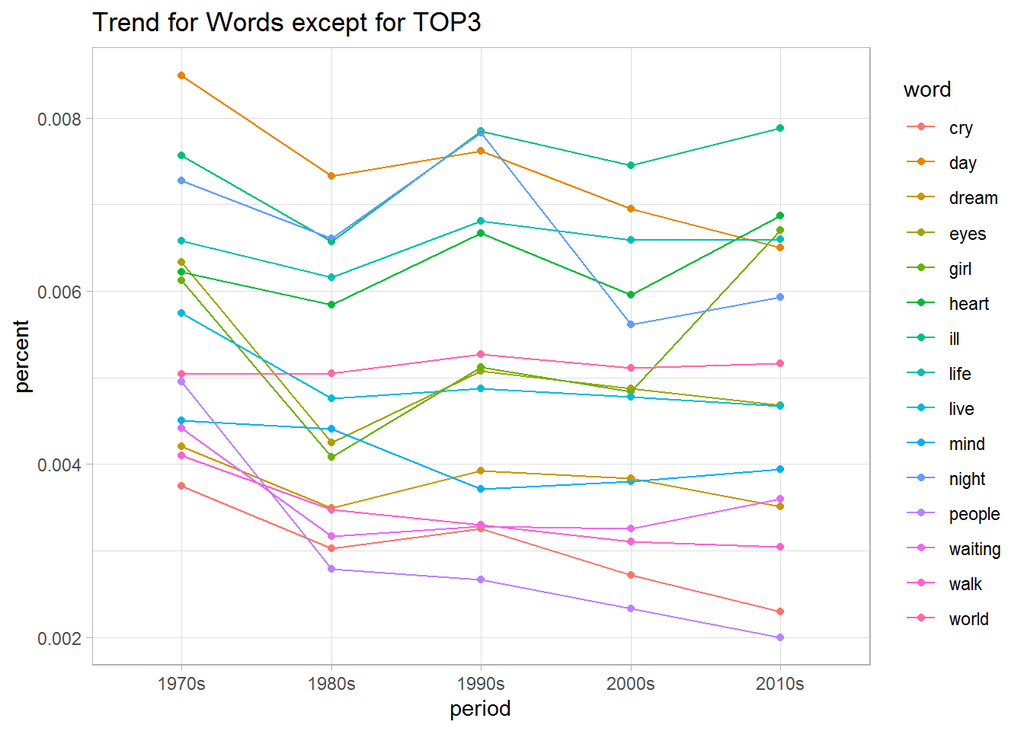

```r
g4<-data[-(1:3),]%>%
  pivot_longer(2:6,names_to = "period",values_to = "percent")%>%
  ggplot()+
  geom_point(aes(period,percent,col = word))+
  geom_line(aes(x = rep(1:5,15),percent,col = word))+
  labs(title = "Trend for Words except for TOP3")+
  theme_light()
g4
```

Still focus on the Top20 Words, on one hand, for the words whose cycle are approximately estimated, it may be possible to estimate the percent of frequency in 2020s compared to 2010s.Deatiled models need to be used to do this estimation. On the other hand, words like “WAITING” whose period is still not known, it’s hard to say what will happen to its frquency in lyrics in the next ten years.